# TET2

Loading the necessary libraries:

Notice that the seqLogo library is from the bioconductor package. First install bioconductor, using the commend install.packages(“BiocManager”). Then install the seqLogo package using BiocManager::install(c(“seqLogo”)). Other packages will be installed automatically on request in rstudio if not present already.

```r
library(readxl)
library(tidyr)
library(purrr)
library(dplyr)
library(seqLogo)
options(digits=12)
```

```r
filename <-"../Datasets/mTET2-CpN-FM-Compilation-Forward_kinetics.xlsx"
sheet <- "CG vs CN"
range1 <- "E27:IV34"
range2 <- "E83:IV83"
range3 <- "E86:IV86"
name <- "TET2"
```

```r
create_df <- function (filename, sheet, range1, range2, range3,name)
{
  options(digits=10)
  TET <- read_excel(filename, sheet = sheet, range = range1, col_names=FALSE) %>% map_df(rev)
  names(TET)<-paste("seq",1:252)
  TET_v1 <- read_excel(filename, sheet = sheet, range = range2,col_types="text", col_names=FALSE)
  names(TET_v1)<-paste("seq",1:252)
  TET_v2 <- read_excel(filename, sheet = sheet, range = range3,col_types="text", col_names=FALSE)
  names(TET_v2)<-paste("seq",1:252)
  TET_all1 <- rbind(TET,TET_v1,TET_v2)
  TET_all2 <- as.data.frame(t(TET_all1))
}
```

```r
shortlogo <- function(model_simple) {
  mycoeff <- coef(summary(model_simple))
  V3_A <-1
  V3_C <-exp(mycoeff["V3C","Estimate"])
  V3_G <-exp(mycoeff["V3G","Estimate"])
  V3_T <-exp(mycoeff["V3T","Estimate"])
  unV3 <-c(V3_A,V3_C,V3_G, V3_T)
  fact <- sum(c(V3_A,V3_C,V3_G, V3_T))
  myV3 <- unV3/fact
  #
  myV4 <- c(0.0,1.0,0.0,0.0)
  #
  V5_A <-1
  V5_C <-exp(mycoeff["V5C","Estimate"])
  V5_G <-exp(mycoeff["V5G","Estimate"])
  V5_T <-exp(mycoeff["V5T","Estimate"])
  unV5 <-c(V5_A,V5_C,V5_G, V5_T)
  fact <- sum(c(V5_A,V5_C,V5_G, V5_T))
  myV5 <- unV5/fact
  #
  V6_A <-1
  V6_C <-exp(mycoeff["V6C","Estimate"])
  V6_G <-exp(mycoeff["V6G","Estimate"])
  V6_T <-exp(mycoeff["V6T","Estimate"])
  unV6 <-c(V6_A,V6_C,V6_G, V6_T)
  fact <- sum(c(V6_A,V6_C,V6_G, V6_T))
  myV6 <- unV6/fact
  logo_input=data.frame(myV3,myV4,myV5,myV6)
  p <- makePWM(logo_input)
  seqLogo(p, ic.scale=FALSE)
}
```

```r
longlogo <-function(model_complex_sample)
{
  mycoeff <- coef(summary(model_complex_sample))
  #
  V2_A <-1
  V2_C <-exp(mycoeff["V2C","Estimate"])
  V2_G <-exp(mycoeff["V2G","Estimate"])
  V2_T <-exp(mycoeff["V2T","Estimate"])
  unV2 <-c(V2_A,V2_C,V2_G, V2_T)
  fact <- sum(c(V2_A,V2_C,V2_G, V2_T))
  myV2 <- unV2/fact
  #
  V3_A <-1
  V3_C <-exp(mycoeff["V3C","Estimate"])
  V3_G <-exp(mycoeff["V3G","Estimate"])
  V3_T <-exp(mycoeff["V3T","Estimate"])
  unV3 <-c(V3_A,V3_C,V3_G, V3_T)
  fact <- sum(c(V3_A,V3_C,V3_G, V3_T))
  myV3 <- unV3/fact
  #
  myV4 <- c(0.0,1.0,0.0,0.0)
  #
  V5_A <-1
  V5_C <-exp(mycoeff["V5C","Estimate"])
  V5_G <-exp(mycoeff["V5G","Estimate"])
  V5_T <-exp(mycoeff["V5T","Estimate"])
  unV5 <-c(V5_A,V5_C,V5_G, V5_T)
  fact <- sum(c(V5_A,V5_C,V5_G, V5_T))
  myV5 <- unV5/fact
  #
  V6_A <-1
  V6_C <-exp(mycoeff["V6C","Estimate"])
  V6_G <-exp(mycoeff["V6G","Estimate"])
  V6_T <-exp(mycoeff["V6T","Estimate"])
  unV6 <-c(V6_A,V6_C,V6_G, V6_T)
  fact <- sum(c(V6_A,V6_C,V6_G, V6_T))
  myV6 <- unV6/fact
  #
  V7_A <-1
  V7_C <-exp(mycoeff["V7C","Estimate"])
  V7_G <-exp(mycoeff["V7G","Estimate"])
  V7_T <-exp(mycoeff["V7T","Estimate"])
  unV7 <-c(V7_A,V7_C,V7_G, V7_T)
  fact <- sum(c(V7_A,V7_C,V7_G, V7_T))
  myV7 <- unV7/fact
  logo_input=data.frame(myV2,myV3,myV4,myV5,myV6,myV7)
  p <- makePWM(logo_input)
  seqLogo(p, ic.scale=FALSE)
}
```

## read in the data

```r
TET=create_df(filename, sheet, range1, range2, range3,name)
```

[output not shown]

```r
TET$V9 <-as.numeric(as.character(TET$V9))
TET$V10 <-as.numeric(as.character(TET$V10))
```

## Compare the two experimental repeats

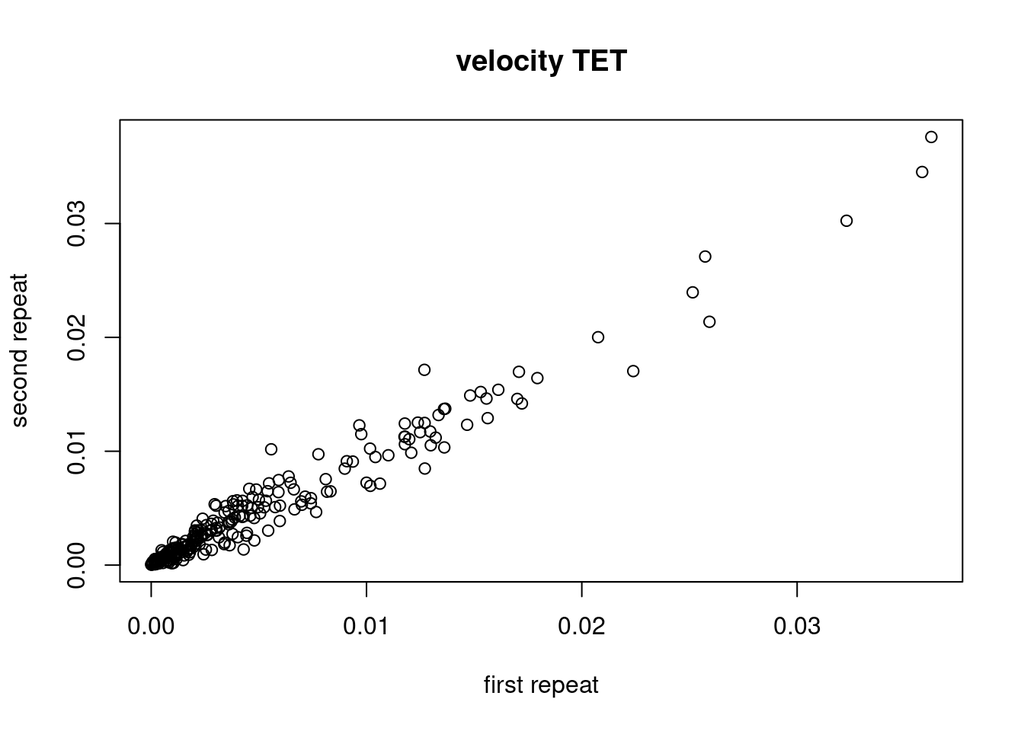

```r
options(digits=8)
plot(TET$V9,TET$V10,main="velocity TET", xlab="first repeat",ylab="second repeat")
```

## Remove negative or extremely low velocities

```r
TET_clean <- TET %>% drop_na()  %>% filter(V9>exp(-12)) %>% filter(V10>exp(-12))
TET_clean <- TET_clean %>% mutate(logV9=log(V9), logV10=log(V10))
TET_clean <- TET_clean %>% mutate(avlogV=(logV9+logV10)/2)
TET_clean <- TET_clean %>% mutate(difflogV=abs(logV9-logV10))
head(TET_clean)
```

```
##       V1 V2 V3 V4 V5 V6 V7 V8            V9           V10      logV9     logV10
## seq 1  A  T  T  C  G  C  C  C 0.00088554096 0.00075302892 -7.0293118 -7.1914069
## seq 2  T  C  G  C  C  C  T  T 0.00103271837 0.00018606066 -6.8755608 -8.5894378
## seq 3  C  G  C  C  C  T  T  T 0.01365695289 0.01373812743 -4.2935065 -4.2875803
## seq 4  G  C  C  C  T  T  T  G 0.00423334183 0.00422791290 -5.4647636 -5.4660468
## seq 5  G  G  G  C  T  G  C  T 0.00025226262 0.00039449146 -8.2850399 -7.8379131
## seq 6  C  T  G  C  T  G  G  A 0.00038303467 0.00054132101 -7.8673851 -7.5214981
##           avlogV     difflogV
## seq 1 -7.1103594 0.1620950788
## seq 2 -7.7324993 1.7138770546
## seq 3 -4.2905434 0.0059262309
## seq 4 -5.4654052 0.0012832443
## seq 5 -8.0614765 0.4471267994
## seq 6 -7.6944416 0.3458869786
```

## Compare log velocities

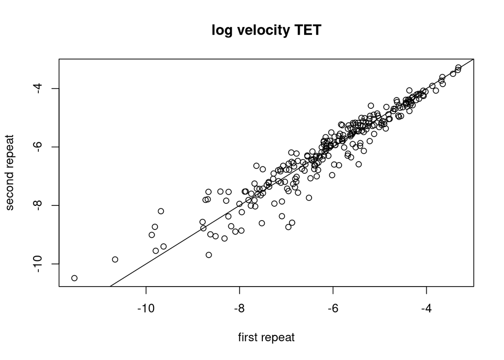

```r
plot(TET_clean$logV9,TET_clean$logV10,main="log velocity TET", xlab="first repeat",ylab="second repeat")
abline(a=0,b=1)
```

Notice that the error here looks like it could well be random

```r
cor(TET_clean$logV9,TET_clean$logV10)
```

```
## [1] 0.95267141
```

## Build a model with three contributing bases and weighting (and C)

```r
model_simple <-lm(avlogV~V3+V5+V6,data=TET_clean,weights=1/(difflogV+0.1))
summary(model_simple)
```

```
##
## Call:
## lm(formula = avlogV ~ V3 + V5 + V6, data = TET_clean, weights = 1/(difflogV +
##     0.1))
##
## Weighted Residuals:
##      Min       1Q   Median       3Q      Max
## -3.62804 -1.03183 -0.05400  0.89907  3.51261
##
## Coefficients:
##             Estimate Std. Error  t value  Pr(>|t|)
## (Intercept) -5.13372    0.15784 -32.5251 < 2.2e-16 ***
## V3C         -0.16357    0.13434  -1.2176  0.224556
## V3G         -1.02067    0.13902  -7.3417 3.229e-12 ***
## V3T         -1.05351    0.15024  -7.0120 2.351e-11 ***
## V5C          0.91439    0.13326   6.8618 5.702e-11 ***
## V5G          1.34677    0.14390   9.3590 < 2.2e-16 ***
## V5T         -0.93866    0.14015  -6.6976 1.481e-10 ***
## V6C         -0.88034    0.13256  -6.6413 2.046e-10 ***
## V6G         -0.42480    0.13878  -3.0609  0.002457 **
## V6T         -0.24767    0.14444  -1.7147  0.087692 .
## ---
## Signif. codes:  0 '***' 0.001 '**' 0.01 '*' 0.05 '.' 0.1 ' ' 1
##
## Residual standard error: 1.4603 on 241 degrees of freedom
## Multiple R-squared:  0.68802,    Adjusted R-squared:  0.67637
## F-statistic: 59.053 on 9 and 241 DF,  p-value: < 2.22e-16
```

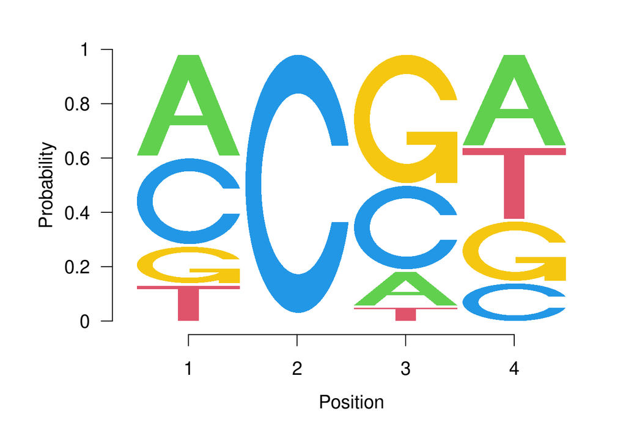

```r
shortlogo(model_simple)
```

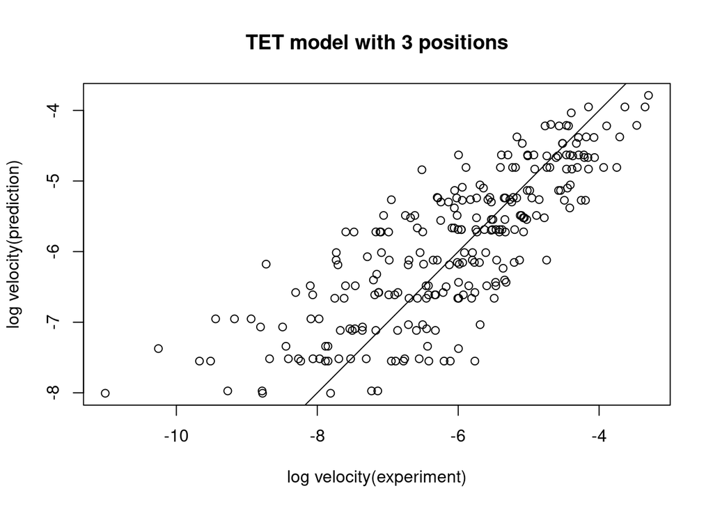

```r
plot(TET_clean$avlogV,as.vector(model_simple$fitted.values),
     main="TET model with 3 positions",
     xlab="log velocity(experiment)",
     ylab="log velocity(prediction)"
     )
abline(a=0,b=1)
```

```r
cor(TET_clean$avlogV,as.vector(model_simple$fitted.values))
```

```
## [1] 0.79302565
```

## Create a model with five contributing bases and weighting

```r
model_complex <-lm(avlogV~V2+V3+V5+V6+V7,data=TET_clean, weights=1/(difflogV+0.1))
summary(model_complex)
```

```
##
## Call:
## lm(formula = avlogV ~ V2 + V3 + V5 + V6 + V7, data = TET_clean,
##     weights = 1/(difflogV + 0.1))
##
## Weighted Residuals:
##      Min       1Q   Median       3Q      Max
## -3.23389 -1.00934 -0.05051  0.72772  3.33080
##
## Coefficients:
##              Estimate Std. Error  t value  Pr(>|t|)
## (Intercept) -5.325789   0.175706 -30.3108 < 2.2e-16 ***
## V2C          0.349362   0.124220   2.8125 0.0053321 **
## V2G          0.454405   0.124649   3.6455 0.0003286 ***
## V2T         -0.143641   0.142356  -1.0090 0.3139980
## V3C         -0.201747   0.128976  -1.5642 0.1191091
## V3G         -1.072325   0.133309  -8.0439 4.279e-14 ***
## V3T         -0.974180   0.148545  -6.5582 3.429e-10 ***
## V5C          0.835966   0.126746   6.5956 2.772e-10 ***
## V5G          1.380993   0.137415  10.0498 < 2.2e-16 ***
## V5T         -0.989988   0.133842  -7.3967 2.454e-12 ***
## V6C         -0.947055   0.129187  -7.3309 3.664e-12 ***
## V6G         -0.448611   0.138087  -3.2487 0.0013286 **
## V6T         -0.320212   0.142030  -2.2545 0.0250843 *
## V7C          0.022910   0.135775   0.1687 0.8661516
## V7G         -0.042051   0.129683  -0.3243 0.7460287
## V7T          0.296841   0.137668   2.1562 0.0320824 *
## ---
## Signif. codes:  0 '***' 0.001 '**' 0.01 '*' 0.05 '.' 0.1 ' ' 1
##
## Residual standard error: 1.3775 on 235 degrees of freedom
## Multiple R-squared:  0.72932,    Adjusted R-squared:  0.71204
## F-statistic: 42.212 on 15 and 235 DF,  p-value: < 2.22e-16
```

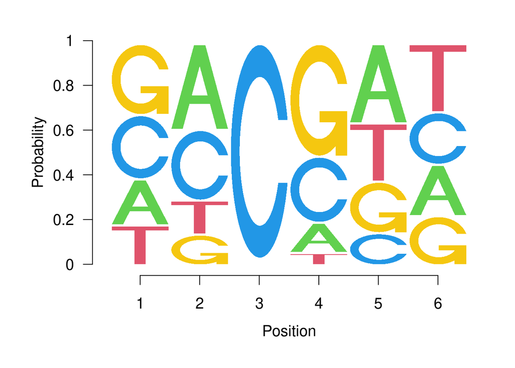

```r
longlogo(model_complex)
```

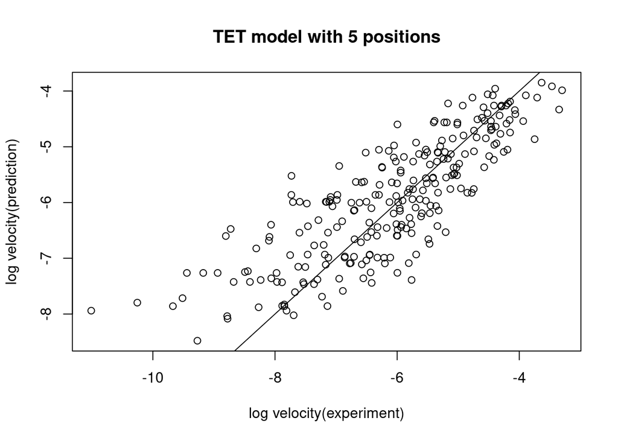

```r
plot(TET_clean$avlogV,as.vector(model_complex$fitted.values),
     main="TET model with 5 positions",
     xlab="log velocity(experiment)",
     ylab="log velocity(prediction)")
abline(a=0,b=1)
```

```r
cor(TET_clean$avlogV,as.vector(model_complex$fitted.values))
```

```
## [1] 0.82053328
```

## Create a model with five contributing bases and weighting, half the data for model

TET_clean_2a will be used to generate the model TET_clean_2b will be used to check the model

```r
ind <- sample(c(TRUE, FALSE), nrow(TET_clean), replace=TRUE, prob=c(0.5, 0.5))
TET_clean_2a<-TET_clean[ind,]
TET_clean_2b<-TET_clean[!ind,]
```

Now build the model with 5 positions and weighting, based on TET_clean_2a

```r
model_complex_sample <-lm(avlogV~V2+V3+V5+V6+V7,data=TET_clean_2a, weights=1/(difflogV+0.1))
summary(model_complex_sample)
```

```
##
## Call:
## lm(formula = avlogV ~ V2 + V3 + V5 + V6 + V7, data = TET_clean_2a,
##     weights = 1/(difflogV + 0.1))
##
## Weighted Residuals:
##       Min        1Q    Median        3Q       Max
## -3.100051 -1.000030 -0.086422  0.605990  3.106346
##
## Coefficients:
##              Estimate Std. Error  t value  Pr(>|t|)
## (Intercept) -5.585570   0.252601 -22.1122 < 2.2e-16 ***
## V2C          0.594984   0.176538   3.3703  0.001018 **
## V2G          0.519736   0.179444   2.8964  0.004507 **
## V2T         -0.029304   0.217632  -0.1346  0.893122
## V3C         -0.230433   0.167817  -1.3731  0.172340
## V3G         -1.095548   0.183712  -5.9634 2.686e-08 ***
## V3T         -1.139315   0.222098  -5.1298 1.164e-06 ***
## V5C          0.915996   0.184893   4.9542 2.473e-06 ***
## V5G          1.245551   0.203966   6.1067 1.366e-08 ***
## V5T         -0.853432   0.204376  -4.1758 5.743e-05 ***
## V6C         -0.833409   0.192486  -4.3297 3.167e-05 ***
## V6G         -0.591510   0.215616  -2.7433  0.007039 **
## V6T         -0.146043   0.210707  -0.6931  0.489615
## V7C          0.229197   0.204386   1.1214  0.264418
## V7G          0.083965   0.188303   0.4459  0.656490
## V7T          0.271244   0.206690   1.3123  0.191981
## ---
## Signif. codes:  0 '***' 0.001 '**' 0.01 '*' 0.05 '.' 0.1 ' ' 1
##
## Residual standard error: 1.391 on 117 degrees of freedom
## Multiple R-squared:  0.74122,    Adjusted R-squared:  0.70805
## F-statistic: 22.342 on 15 and 117 DF,  p-value: < 2.22e-16
```

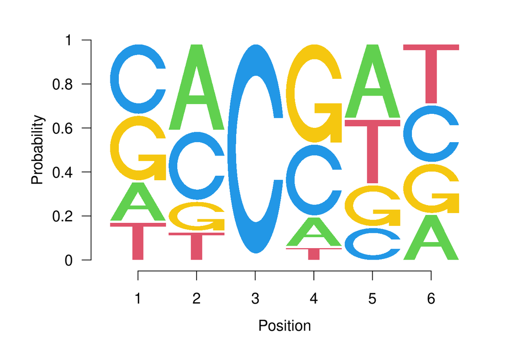

```r
longlogo(model_complex_sample)
```

check how well the model fits the data that have been used for its calculation

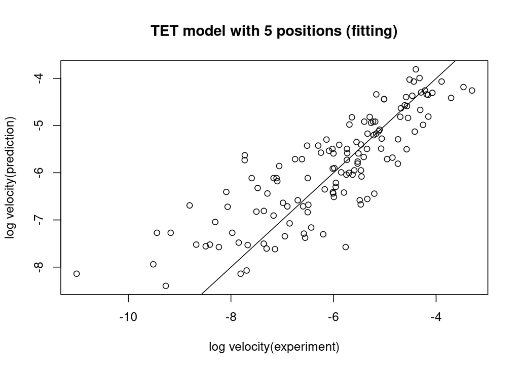

```r
plot(TET_clean_2a$avlogV,predict(model_complex_sample,TET_clean_2a),
     main="TET model with 5 positions (fitting)",
     xlab="log velocity(experiment)",
     ylab="log velocity(prediction)")
abline(a=0,b=1)
```

```r
cor(TET_clean_2a$avlogV,predict(model_complex_sample,TET_clean_2a))
```

```
## [1] 0.83203292
```

check the quality of the model with the other half of the data

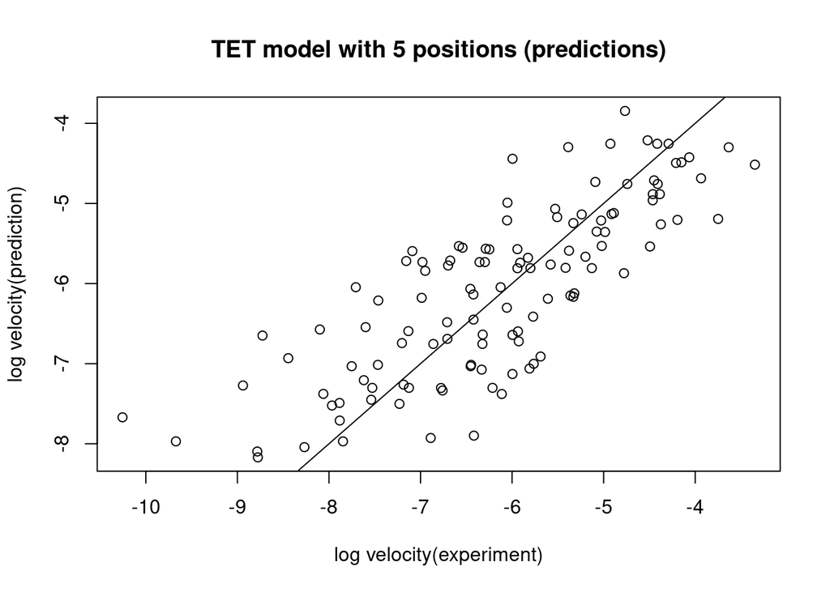

```r
plot(TET_clean_2b$avlogV,predict(model_complex_sample,TET_clean_2b),
     main="TET model with 5 positions (predictions)",
     xlab="log velocity(experiment)",
     ylab="log velocity(prediction)")
abline(a=0,b=1)
```

```r
cor(TET_clean_2b$avlogV,predict(model_complex_sample,TET_clean_2b))
```

```
## [1] 0.79055357
```